# 560 Lecture 5 - T tests

Douglas M. Fowler

3/26/2017

```r
library(ggplot2)
```

## One Sample t-Test

```r
ww_data = read.table(file="http://faculty.washington.edu/dfowler/teaching/2017/GNOM560/560_ww_data.txt", header = T, sep = '\t')
```

#### Now, let’s do t-test (two-sided) to see if the sample mean deviates from 0

```r
t.test(ww_data$scaled_effect, mu = 0)
```

```
##
##  One Sample t-test
##
## data:  ww_data$scaled_effect
## t = 57.11, df = 376, p-value < 2.2e-16
## alternative hypothesis: true mean is not equal to 0
## 95 percent confidence interval:
##  0.8019972 0.8591921
## sample estimates:
## mean of x
## 0.8305947
```

#### Let’s learn how to specify the alternative hypothesis

```r
t.test(ww_data$scaled_effect, mu = 0, alternative = "two.sided")
```

```
##
##  One Sample t-test
##
## data:  ww_data$scaled_effect
## t = 57.11, df = 376, p-value < 2.2e-16
## alternative hypothesis: true mean is not equal to 0
## 95 percent confidence interval:
##  0.8019972 0.8591921
## sample estimates:
## mean of x
## 0.8305947
```

```r
t.test(ww_data$scaled_effect, mu = 0, alternative = "less")
```

```
##
##  One Sample t-test
##
## data:  ww_data$scaled_effect
## t = 57.11, df = 376, p-value = 1
## alternative hypothesis: true mean is less than 0
## 95 percent confidence interval:
##       -Inf 0.8545763
## sample estimates:
## mean of x
## 0.8305947
```

```r
t.test(ww_data$scaled_effect, mu = 0, alternative = "greater")
```

```
##
##  One Sample t-test
##
## data:  ww_data$scaled_effect
## t = 57.11, df = 376, p-value < 2.2e-16
## alternative hypothesis: true mean is greater than 0
## 95 percent confidence interval:
##  0.8066131       Inf
## sample estimates:
## mean of x
## 0.8305947
```

## Two Sample t-Test

```r
pab_data = read.table(file="http://faculty.washington.edu/dfowler/teaching/2017/GNOM560/560_pab_data.txt", header = T, sep = '\t') # Load up another DMS (of the yeast protein Pab1) as a comparator
```

#### First, we should check our assumptions about this data. Let’s start with normality, assessed visually.

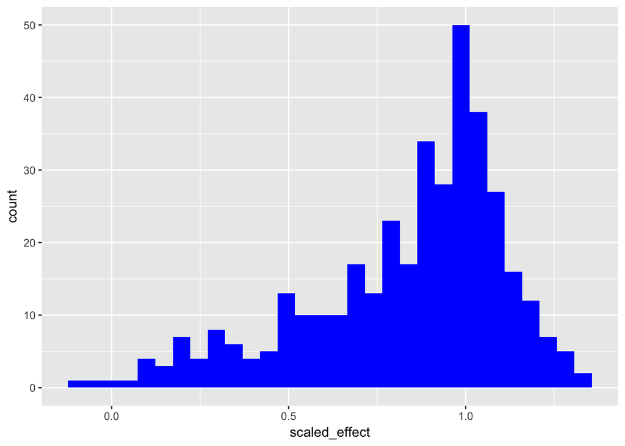

```r
ggplot(ww_data, aes(scaled_effect)) + geom_histogram(fill = "blue")
```

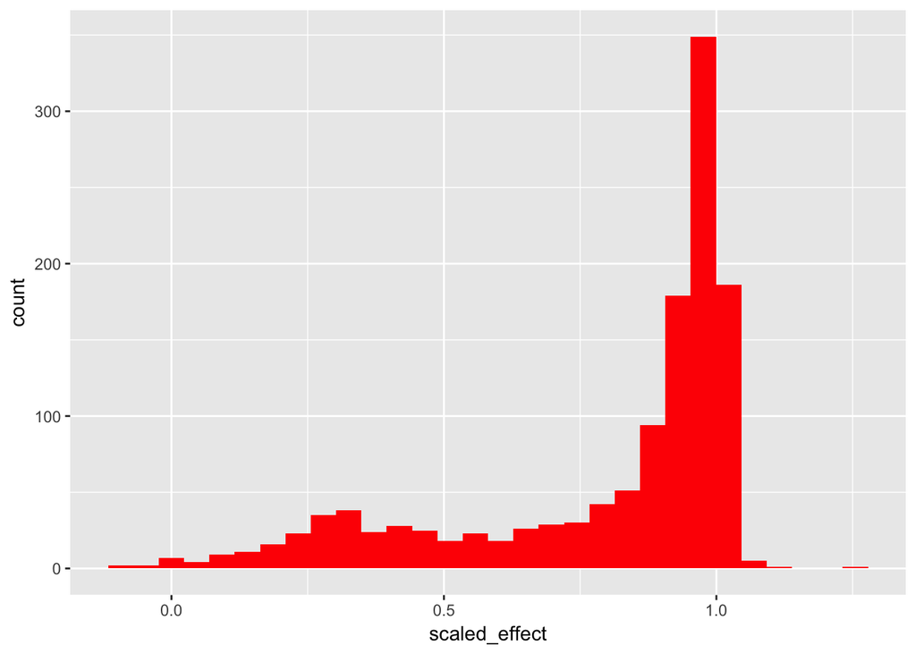

```r
ggplot(pab_data, aes(scaled_effect)) + geom_histogram(fill = "red")
```

#### We can make a Q-Q plot, too.

A Q-Q plot is a graphical method for comparing two probability distributions by plotting their quantiles against each other. A point on the plot corresponds to a quantile of the first distribution plotted against the same quantile of the second distribution. If the distributions are identical, the points will lie on a line with a slope of 1. If they have the same shape but are related by a linear transformation, the Q-Q plot will be linear but with a slope other than 1. Q-Q plots allow you to spot outliers.

Here is a Q-Q plot of randomly generated datasets of 100 observations that drawn from normal distributions with identical parameters

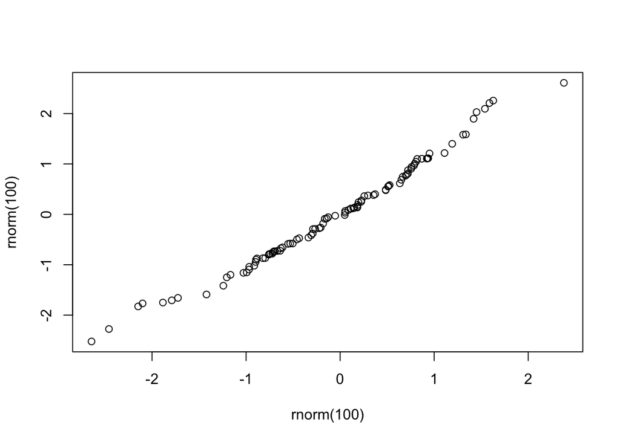

```r
par(mfrow=c(1,1))
qqplot(rnorm(100), rnorm(100))
```

Here is one for a random normal and a random gamma

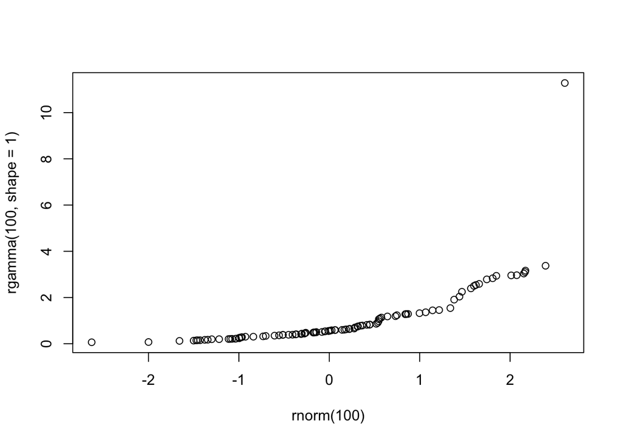

```r
qqplot(rnorm(100), rgamma(100, shape=1))
```

Now, make Q-Q plots comparing your scaled_effect scores and the Pab1 scaled_effect scores to normal distributions with the mean and sd of the actual data

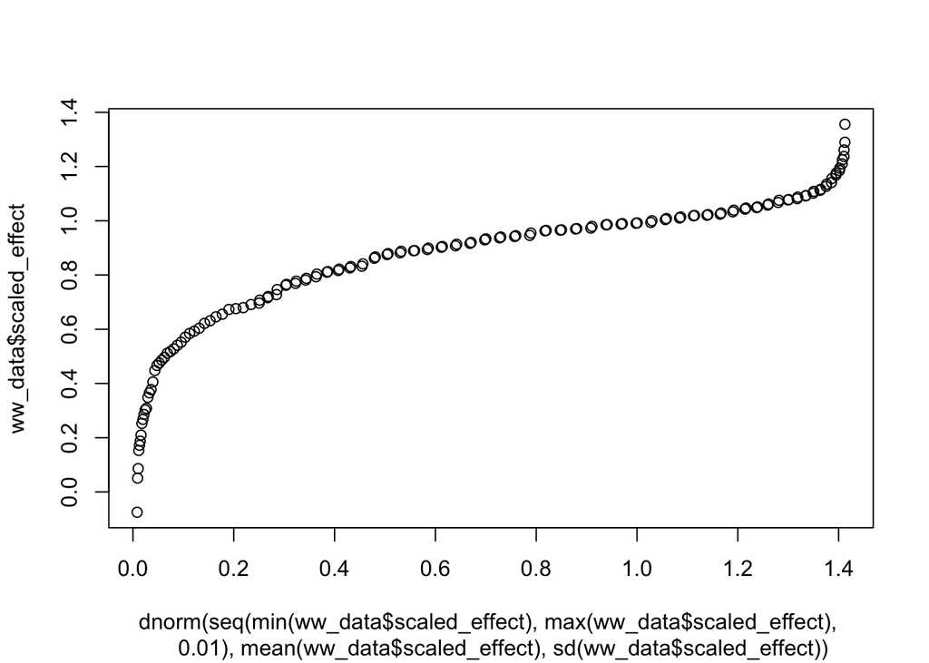

```r
qqplot(dnorm(seq(min(ww_data$scaled_effect), max(ww_data$scaled_effect), 0.01), mean(ww_data$scaled_effect), sd(ww_data$scaled_effect)), ww_data$scaled_effect)
```

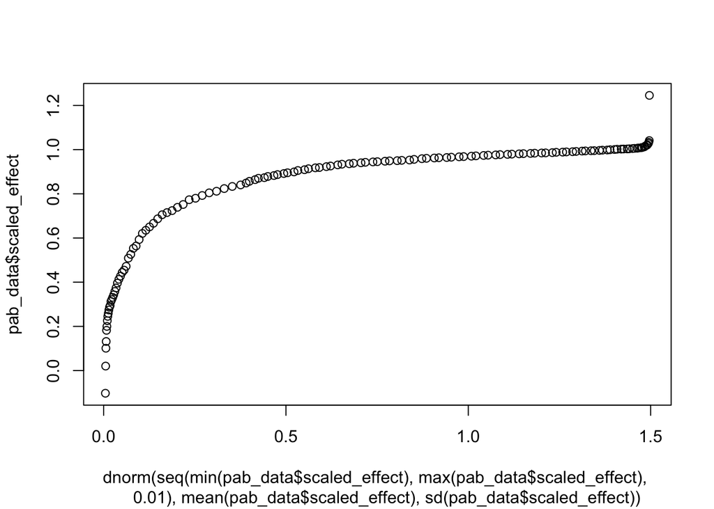

```r
qqplot(dnorm(seq(min(pab_data$scaled_effect), max(pab_data$scaled_effect), 0.01), mean(pab_data$scaled_effect), sd(pab_data$scaled_effect)), pab_data$scaled_effect)
```

Next, compare the distribution of the Pab1 scaled_effect data to your data using a Q-Q plot

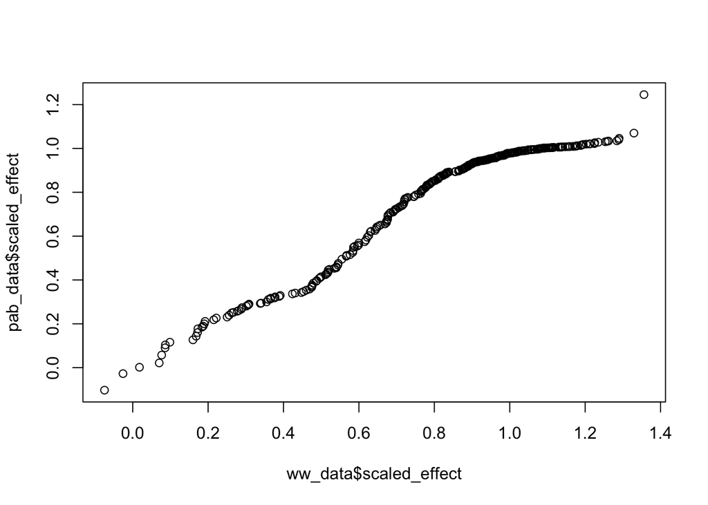

```r
qqplot(ww_data$scaled_effect, pab_data$scaled_effect)
```

#### The Kolmogorov-Smirnov test is a nonparametric test that can be used to compare a sample distribution ot a reference distribution or to compare two sample distributions.

Try to use the Kolmogorov-Smirnov test (ks.test()) to check for normality. As we’ll learn, the KS test compares a set of data to a cumulative distribution function. Here, you will want to use “pnorm” (the normal cumulative distribution function).

```r
ks.test(ww_data$scaled_effect, "pnorm", mean(ww_data$scaled_effect), sd(ww_data$scaled_effect))
```

```
##
##  One-sample Kolmogorov-Smirnov test
##
## data:  ww_data$scaled_effect
## D = 0.13099, p-value = 4.812e-06
## alternative hypothesis: two-sided
```

```r
ks.test(pab_data$scaled_effect, "pnorm", mean(pab_data$scaled_effect), sd(pab_data$scaled_effect))
```

```
##
##  One-sample Kolmogorov-Smirnov test
##
## data:  pab_data$scaled_effect
## D = 0.2313, p-value < 2.2e-16
## alternative hypothesis: two-sided
```

#### Bartlett’s test can be used to determine if samples are drawn from populations with the same variance.

Try to use Bartlett’s test (bartlett.test()) test to see if the variances can be pooled.

```r
bartlett.test(list(ww_data$scaled_effect, pab_data$scaled_effect))
```

```
##
##  Bartlett test of homogeneity of variances
##
## data:  list(ww_data$scaled_effect, pab_data$scaled_effect)
## Bartlett's K-squared = 1.9762, df = 1, p-value = 0.1598
```

Now, do the appropriate t-test (two-sided). Note that for the DMS data, you probably found that the data set isn’t really normal. A question that arises is why is it OK to do a t-test here?

```r
t.test(ww_data$scaled_effect, pab_data$scaled_effect, paired=FALSE,var.equal=TRUE)
```

```
##
##  Two Sample t-test
##
## data:  ww_data$scaled_effect and pab_data$scaled_effect
## t = 1.898, df = 1651, p-value = 0.05788
## alternative hypothesis: true difference in means is not equal to 0
## 95 percent confidence interval:
##  -0.001004963  0.061135480
## sample estimates:
## mean of x mean of y
## 0.8305947 0.8005294
```

Let’s learn how to specify the alternative hypothesis (one-sided)

```r
t.test(ww_data$scaled_effect, pab_data$scaled_effect, paired=FALSE, alternative = "less")
```

```
##
##  Welch Two Sample t-test
##
## data:  ww_data$scaled_effect and pab_data$scaled_effect
## t = 1.8393, df = 587.98, p-value = 0.9668
## alternative hypothesis: true difference in means is less than 0
## 95 percent confidence interval:
##       -Inf 0.0569949
## sample estimates:
## mean of x mean of y
## 0.8305947 0.8005294
```

```r
t.test(ww_data$scaled_effect, pab_data$scaled_effect, paired=FALSE, alternative = "greater")
```

```
##
##  Welch Two Sample t-test
##
## data:  ww_data$scaled_effect and pab_data$scaled_effect
## t = 1.8393, df = 587.98, p-value = 0.03319
## alternative hypothesis: true difference in means is greater than 0
## 95 percent confidence interval:
##  0.003135615         Inf
## sample estimates:
## mean of x mean of y
## 0.8305947 0.8005294
```

#### Do the results make sense?

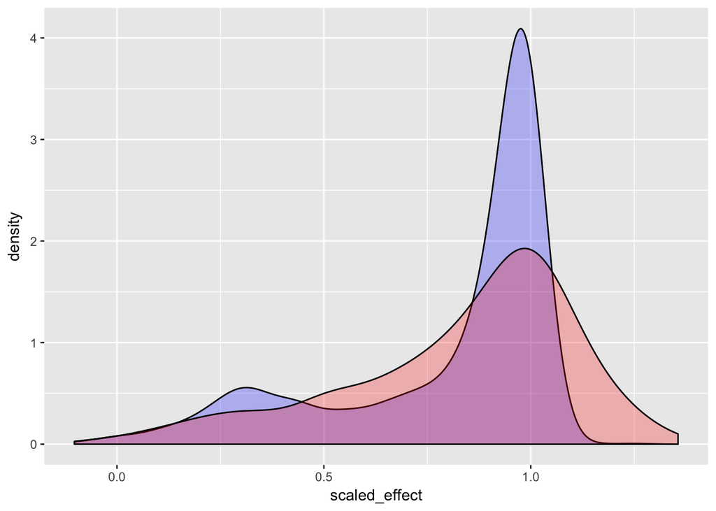

```r
ggplot(pab_data, aes(scaled_effect)) + geom_density(fill = "blue", alpha = 0.25) + geom_density(data = ww_data, aes(scaled_effect), fill = "red", alpha = 0.25) # Note that we can add additional layers to a plot in ggplot really easily.  New layers can even come from a different dataset!
```

```r
mean(pab_data$scaled_effect)
```

```
## [1] 0.8005294
```

```r
mean(ww_data$scaled_effect)
```

```
## [1] 0.8305947
```

#### If we look at the way the data are distributed and each sample mean, it makes sense that they likely are drawn from distributions with the same mean.